# Importing Libraries and Modules

```python
import pandas as pd
import matplotlib.pyplot as plt
import seaborn as sns
import warnings
warnings.filterwarnings('ignore')
```

# Loading the Dataset

```python
file_path = '/content/foodhub_order (1).csv'
data = pd.read_csv(file_path)
```

# Read the Given Dataset

```python
data.head()
```

|  | order_id | customer_id | restaurant_name | cuisine_type | cost_of_the_order | day_of_the_week | rating | food_preparation_time | delivery_time |
| --- | --- | --- | --- | --- | --- | --- | --- | --- | --- |
| 0 | 1477147 | 337525 | Hangawi | Korean | 30.75 | Weekend | Not given | 25 | 20 |
| 1 | 1477685 | 358141 | Blue Ribbon Sushi Izakaya | Japanese | 12.08 | Weekend | Not given | 25 | 23 |
| 2 | 1477070 | 66393 | Cafe Habana | Mexican | 12.23 | Weekday | 5 | 23 | 28 |
| 3 | 1477334 | 106968 | Blue Ribbon Fried Chicken | American | 29.20 | Weekend | 3 | 25 | 15 |
| 4 | 1478249 | 76942 | Dirty Bird to Go | American | 11.59 | Weekday | 4 | 25 | 24 |

# Structure of the Dataset

1.Shape of the dataset 2.Columns of Dataset 3.Types of each Column 4.Statistics of numerical columns 5.Unique values in each Column

```python
print("Shape of the dataset:", data.shape)
```

```
Shape of the dataset: (1898, 9)
```

```python
print("\nColumns in the dataset:", data.columns)
```

```
Columns in the dataset: Index(['order_id', 'customer_id', 'restaurant_name', 'cuisine_type',
       'cost_of_the_order', 'day_of_the_week', 'rating',
       'food_preparation_time', 'delivery_time'],
      dtype='object')
```

```python
print("\nData types of each column:\n", data.dtypes)
```

```
Data types of each column:
 order_id                   int64
customer_id                int64
restaurant_name           object
cuisine_type              object
cost_of_the_order        float64
day_of_the_week           object
rating                    object
food_preparation_time      int64
delivery_time              int64
dtype: object
```

```python
print("\nSummary statistics:\n", data.describe())
```

```
Summary statistics:
            order_id    customer_id  cost_of_the_order  food_preparation_time  \
count  1.898000e+03    1898.000000        1898.000000            1898.000000
mean   1.477496e+06  171168.478398          16.498851              27.371970
std    5.480497e+02  113698.139743           7.483812               4.632481
min    1.476547e+06    1311.000000           4.470000              20.000000
25%    1.477021e+06   77787.750000          12.080000              23.000000
50%    1.477496e+06  128600.000000          14.140000              27.000000
75%    1.477970e+06  270525.000000          22.297500              31.000000
max    1.478444e+06  405334.000000          35.410000              35.000000

       delivery_time
count    1898.000000
mean       24.161749
std         4.972637
min        15.000000
25%        20.000000
50%        25.000000
75%        28.000000
max        33.000000
```

```python
print("\nUnique values in each column:\n", data.nunique())
```

```
Unique values in each column:
 order_id                 1898
customer_id              1200
restaurant_name           178
cuisine_type               14
cost_of_the_order         312
day_of_the_week             2
rating                      4
food_preparation_time      16
delivery_time              19
dtype: int64
```

# Question 1:How many rows and columns are present in the data?

No.of rows and columns in Data

```python
num_rows, num_columns = data.shape
print("Number of rows:", num_rows)
print("Number of columns:", num_columns)
```

```
Number of rows: 1898
Number of columns: 9
```

# Question 2:What are the datatypes of the different columns in the dataset? (The info() function can be used)

Data types using info() function

```python
data.info()
```

```
<class 'pandas.core.frame.DataFrame'>
RangeIndex: 1898 entries, 0 to 1897
Data columns (total 9 columns):
 #   Column                 Non-Null Count  Dtype
---  ------                 --------------  -----
 0   order_id               1898 non-null   int64
 1   customer_id            1898 non-null   int64
 2   restaurant_name        1898 non-null   object
 3   cuisine_type           1898 non-null   object
 4   cost_of_the_order      1898 non-null   float64
 5   day_of_the_week        1898 non-null   object
 6   rating                 1898 non-null   object
 7   food_preparation_time  1898 non-null   int64
 8   delivery_time          1898 non-null   int64
dtypes: float64(1), int64(4), object(4)
memory usage: 133.6+ KB
```

# Question 3:Are there any missing values in the data? If yes, treat them using an appropriate method

Missing Values Verification

```python
missing_values = data.isnull().sum()
print("Missing values in each column:\n", missing_values)
```

```
Missing values in each column:
 order_id                 0
customer_id              0
restaurant_name          0
cuisine_type             0
cost_of_the_order        0
day_of_the_week          0
rating                   0
food_preparation_time    0
delivery_time            0
dtype: int64
```

# Question 4:Check the statistical summary of the data. What is the minimum, average, and maximum time it takes for food to be prepared once an order is placed?

Statistics Summary

```python
statistical_summary = data.describe()
print("Statistical summary of the data:\n", statistical_summary)
```

```
Statistical summary of the data:
            order_id    customer_id  cost_of_the_order  food_preparation_time  \
count  1.898000e+03    1898.000000        1898.000000            1898.000000
mean   1.477496e+06  171168.478398          16.498851              27.371970
std    5.480497e+02  113698.139743           7.483812               4.632481
min    1.476547e+06    1311.000000           4.470000              20.000000
25%    1.477021e+06   77787.750000          12.080000              23.000000
50%    1.477496e+06  128600.000000          14.140000              27.000000
75%    1.477970e+06  270525.000000          22.297500              31.000000
max    1.478444e+06  405334.000000          35.410000              35.000000

       delivery_time
count    1898.000000
mean       24.161749
std         4.972637
min        15.000000
25%        20.000000
50%        25.000000
75%        28.000000
max        33.000000
```

Minimum,Average and Maximum time taken to prepare food

```python
min_time = data['food_preparation_time'].min()
avg_time = data['food_preparation_time'].mean()
max_time = data['food_preparation_time'].max()
```

```python
print(f"\nMinimum food preparation time: {min_time} minutes")
print(f"Average food preparation time: {avg_time:.2f} minutes")
print(f"Maximum food preparation time: {max_time} minutes")
```

```
Minimum food preparation time: 20 minutes
Average food preparation time: 27.37 minutes
Maximum food preparation time: 35 minutes
```

## Question 5:How many orders are not rated?

Count of not rated food

```python
not_rated_count = data[data['rating'] == 'Not given'].shape[0]
print("Number of orders not rated:", not_rated_count)
```

```
Number of orders not rated: 736
```

# Question 6:Explore all the variables and provide observations on their distributions. (Generally, histograms, boxplots, countplots, etc. are used for univariate exploration)

Aesthetic style of the plots

```python
sns.set(style='whitegrid')
```

Created a Figure with subplots

[figure not shown]

```python
fig, axes = plt.subplots(3, 2, figsize=(15, 15))
```

Histogram

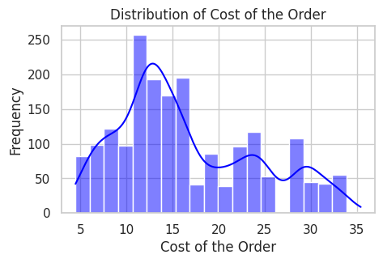

```python
plt.figure(figsize=(5, 3))
sns.histplot(data['cost_of_the_order'], bins=20, kde=True, color='blue')
plt.title('Distribution of Cost of the Order')
plt.xlabel('Cost of the Order')
plt.ylabel('Frequency')
plt.show()
```

Boxplot

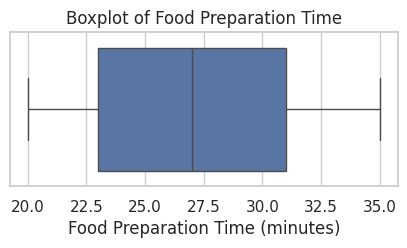

```python
plt.figure(figsize=(5, 2))
sns.boxplot(x=data['food_preparation_time'])
plt.title('Boxplot of Food Preparation Time')
plt.xlabel('Food Preparation Time (minutes)')
plt.show()
```

Countplot

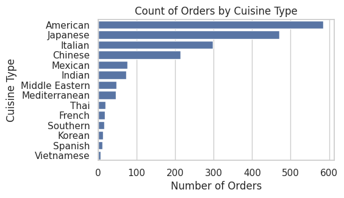

```python
plt.figure(figsize=(5, 3))
sns.countplot(y='cuisine_type', data=data, order=data['cuisine_type'].value_counts().index)
plt.title('Count of Orders by Cuisine Type')
plt.xlabel('Number of Orders')
plt.ylabel('Cuisine Type')
plt.show()
```

# Question 7:Which are the top 5 restaurants in terms of the number of orders received?

Top 5 Restaurants

```python
top_restaurants = data['restaurant_name'].value_counts().head(5)
print("Top 5 restaurants in terms of number of orders:")
print(top_restaurants)
```

```
Top 5 restaurants in terms of number of orders:
restaurant_name
Shake Shack                  219
The Meatball Shop            132
Blue Ribbon Sushi            119
Blue Ribbon Fried Chicken     96
Parm                          68
Name: count, dtype: int64
```

# Question 8:Which is the most popular cuisine on weekends?

Checking Unique value in a week

```python
print(data['day_of_the_week'].unique())
```

```
['Weekend' 'Weekday']
```

checking the order in weekend

```python
weekend_data = data[data['day_of_the_week'].isin(['Saturday', 'Sunday'])]
print(weekend_data)
```

```
Empty DataFrame
Columns: [order_id, customer_id, restaurant_name, cuisine_type, cost_of_the_order, day_of_the_week, rating, food_preparation_time, delivery_time]
Index: []
```

Availability in Weekend

```python
weekend_data = data[data['day_of_the_week'].isin(['Saturday', 'Sunday'])]
if not weekend_data.empty:
    popular_cuisine_weekend = weekend_data['cuisine_type'].value_counts().idxmax()
    print("The most popular cuisine on weekends is:", popular_cuisine_weekend)
else:
    print("No data available for weekends.")
```

[output not shown]

# Question 9: What percentage of the orders cost more than 20 dollars?

Total number of orders

```python
total_orders = len(data)
```

Orders above 20 dollars in Count and Percentage

```python
orders_above_20 = len(data[data['cost_of_the_order'] > 20])
percentage_above_20 = (orders_above_20 / total_orders) * 100
print(f"Number of orders costing more than 20 dollars: {orders_above_20}")
print(f"Percentage of orders costing more than 20 dollars: {percentage_above_20:.2f}%")
```

```
Number of orders costing more than 20 dollars: 555
Percentage of orders costing more than 20 dollars: 29.24%
```

# Question 10: What is the mean order delivery time?

Mean of Delivery time

```python
mean_delivery_time = data['delivery_time'].mean()
print(f"The mean order delivery time is: {mean_delivery_time:.2f} minutes")
```

```
The mean order delivery time is: 24.16 minutes
```

# Question 11:The company has decided to give 20% discount vouchers to the top 3 most frequent customers. Find the IDs of these customers and the number of orders they placed

Top 3 Customers ID and numbers of orders placed by them

```python
top_customers = data['customer_id'].value_counts().head(3)
print("Top 3 most frequent customers and the number of orders they placed:")
print(top_customers)
```

```
Top 3 most frequent customers and the number of orders they placed:
customer_id
52832    13
47440    10
83287     9
Name: count, dtype: int64
```

# Question 12: Perform a multivariate analysis to explore relationships between the important variables in the dataset. (It is a good idea to explore relations between numerical variables as well as relations between numerical and categorical variables)

Replacing Non-Numerical with Nan

```python
data['rating'] = pd.to_numeric(data['rating'], errors='coerce')
```

```python
correlation_matrix = data[['cost_of_the_order', 'delivery_time', 'food_preparation_time', 'rating']].corr()
```

HeatMap

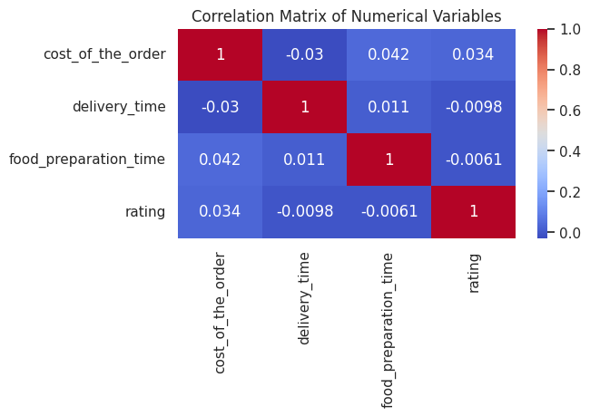

```python
plt.figure(figsize=(6, 3))
sns.heatmap(correlation_matrix, annot=True, cmap='coolwarm')
plt.title("Correlation Matrix of Numerical Variables")
plt.show()
```

pairplot to numerical Variables

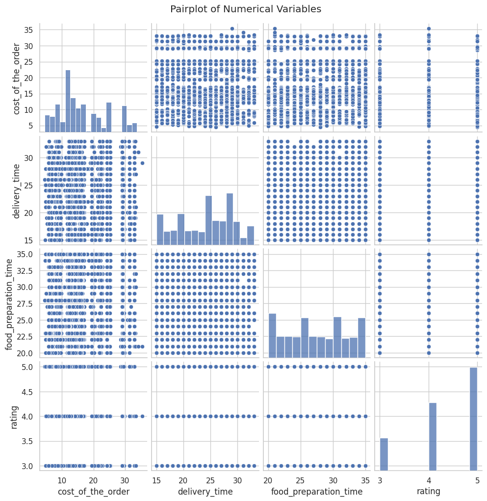

```python
sns.pairplot(data[['cost_of_the_order', 'delivery_time', 'food_preparation_time', 'rating']])
plt.suptitle("Pairplot of Numerical Variables", y=1.02)
plt.show()
```

Boxplot to compare 'cost_of_the_order' across 'cuisine_type'

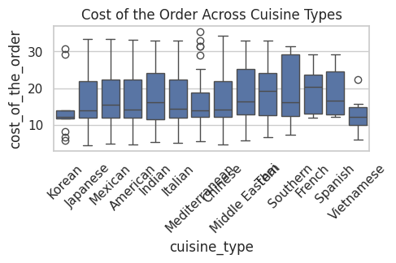

```python
plt.figure(figsize=(5, 2))
sns.boxplot(x='cuisine_type', y='cost_of_the_order', data=data)
plt.xticks(rotation=45)
plt.title("Cost of the Order Across Cuisine Types")
plt.show()
```

Violin plot to compare 'delivery_time' across 'day_of_the_week'

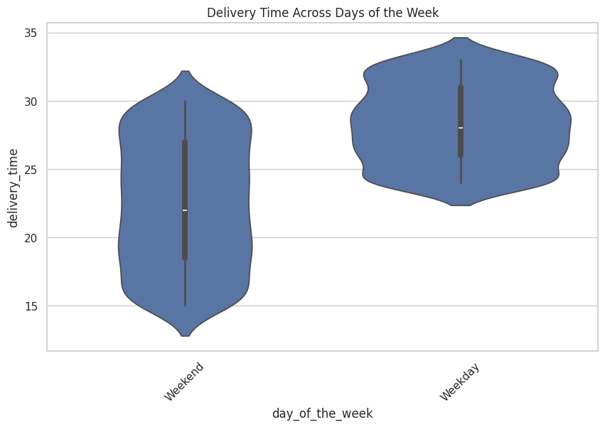

```python
plt.figure(figsize=(10, 6))
sns.violinplot(x='day_of_the_week', y='delivery_time', data=data)
plt.xticks(rotation=45)
plt.title("Delivery Time Across Days of the Week")
plt.show()
```

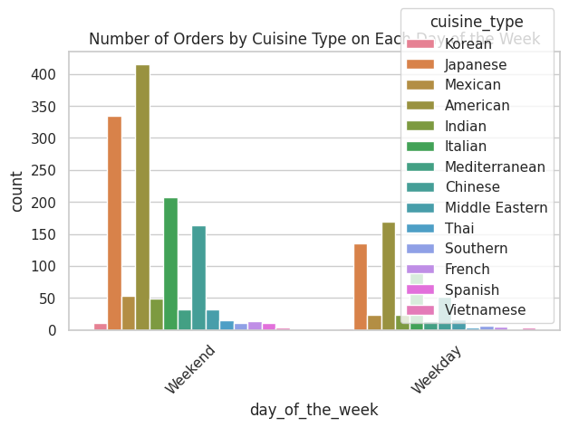

```python
plt.figure(figsize=(7, 4))
sns.countplot(x='day_of_the_week', hue='cuisine_type', data=data)
plt.xticks(rotation=45)
plt.title("Number of Orders by Cuisine Type on Each Day of the Week")
plt.show()
```

# Question 13:The company wants to provide a promotional offer in the advertisement of the restaurants. The condition to get the offer is that the restaurants must have a rating count of more than 50 and the average rating should be greater than 4. Find the restaurants fulfilling the criteria to get the promotional offer

Group by 'restaurant_name' and calculate the rating count and average rating

```python
restaurant_stats = data.groupby('restaurant_name')['rating'].agg(['count', 'mean']).reset_index()
```

Rename the columns for clarity

```python
restaurant_stats.columns = ['restaurant_name', 'rating_count', 'average_rating']
```

Filter restaurants that fulfill the criteria

```python
promotional_restaurants = restaurant_stats[(restaurant_stats['rating_count'] > 50) & (restaurant_stats['average_rating'] > 4)]
print("Restaurants fulfilling the criteria for the promotional offer:")
print(promotional_restaurants)
```

```
Restaurants fulfilling the criteria for the promotional offer:
               restaurant_name  rating_count  average_rating
20   Blue Ribbon Fried Chicken            64        4.328125
21           Blue Ribbon Sushi            73        4.219178
136                Shake Shack           133        4.278195
153          The Meatball Shop            84        4.511905
```

# Question 14:The company charges the restaurant 25% on the orders having cost greater than 20 dollars and 15% on the orders having cost greater than 5 dollars. Find the net revenue generated by the company across all orders

Initialize a revenue column

```python
data['revenue'] = 0.0
```

Calculate revenue based on the cost of orders

```python
data.loc[data['cost_of_the_order'] > 20, 'revenue'] = data['cost_of_the_order'] * 0.25
data.loc[(data['cost_of_the_order'] <= 20) & (data['cost_of_the_order'] > 5), 'revenue'] = data['cost_of_the_order'] * 0.15
```

Calculate total revenue

```python
total_revenue = data['revenue'].sum()
print(f"Total net revenue generated by the company across all orders: ${total_revenue:.2f}")
```

```
Total net revenue generated by the company across all orders: $6166.30
```

# Question 15:The company wants to analyze the total time required to deliver the food. What percentage of orders take more than 60 minutes to get delivered from the time the order is placed? (The food has to be prepared and then delivered)

Calculation of time required

```python
data['total_time'] = data['food_preparation_time'] + data['delivery_time']
```

No.of Orders taking more than 60 min

```python
orders_above_60 = data[data['total_time'] > 60].shape[0]
print(f"Count of orders taking more than 60 minutes: {orders_above_60}")
```

```
Count of orders taking more than 60 minutes: 200
```

Calculation in percentage

```python
percentage_above_60 = (orders_above_60 / total_orders) * 100
print(f"Percentage of orders taking more than 60 minutes to be delivered: {percentage_above_60:.2f}%")
```

```
Percentage of orders taking more than 60 minutes to be delivered: 10.54%
```

# Question 16:The company wants to analyze the delivery time of the orders on weekdays and weekends. How does the mean delivery time vary during weekdays and weekends?

Analyze the delivery time on weekdays and weekends.

```python
data['day_type'] = data['day_of_the_week'].apply(lambda x: 'Weekend' if x in ['Saturday', 'Sunday'] else 'Weekday')
```

Mean Delivery time on weekdays and weekends

```python
mean_delivery_time = data.groupby('day_type')['delivery_time'].mean()
print("Mean delivery time on weekdays and weekends:")
print(mean_delivery_time)
```

[output not shown]

# Question 17:What are your conclusions from the analysis? What recommendations would you like to share to help improve the business? (You can use cuisine type and feedback ratings to drive your business recommendations)

Function without recursion and Average rating by cuisine type

```
Average Ratings by Cuisine Type:
cuisine_type
Spanish           4.833333
Thai              4.666667
Indian            4.540000
Mexican           4.416667
Japanese          4.373626
Italian           4.360465
Chinese           4.338346
Southern          4.307692
French            4.300000
American          4.298913
Middle Eastern    4.235294
Mediterranean     4.218750
Korean            4.111111
Vietnamese        4.000000
Name: rating, dtype: float64
```

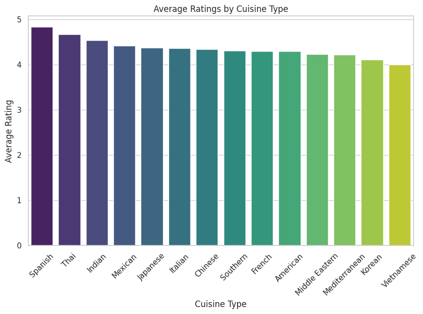

```python
def analyze_cuisine_and_ratings(data):
    avg_ratings_by_cuisine = data.groupby('cuisine_type')['rating'].mean().sort_values(ascending=False)
    print("Average Ratings by Cuisine Type:")
    print(avg_ratings_by_cuisine)
    plt.figure(figsize=(10, 6))
    sns.barplot(x=avg_ratings_by_cuisine.index, y=avg_ratings_by_cuisine.values, palette='viridis')
    plt.xticks(rotation=45)
    plt.title('Average Ratings by Cuisine Type')
    plt.ylabel('Average Rating')
    plt.xlabel('Cuisine Type')
    plt.show()
analyze_cuisine_and_ratings(data)
```

Recommendations

```python
recommendations = """
Recommendations from Myside:

1. Improve Restaurant Quality:
   - Provide feedback mechanisms for restaurants with low ratings.
   - Offer training sessions on food preparation and customer service.

2. Menu Optimization:
   - Focus on promoting the most popular cuisines, especially on weekends.
   - Introduce special offers or meal bundles.

3. Enhance Delivery Operations:
   - Analyze delivery times to identify inefficiencies.
   - Hire additional delivery personnel during peak times.

4. Loyalty Programs:
   - Introduce loyalty programs for frequent customers with discounts or freebies.

5. Promotional Offers:
   - Design targeted promotions based on data insights.

6. Customer Feedback:
   - Encourage feedback and analyze it for actionable insights.

7. Analyze Pricing Strategy:
   - Examine correlation between order cost and customer satisfaction for potential pricing adjustments.
"""

print(recommendations)
```

```
Recommendations from Myside:

1. Improve Restaurant Quality:
   - Provide feedback mechanisms for restaurants with low ratings.
   - Offer training sessions on food preparation and customer service.

2. Menu Optimization:
   - Focus on promoting the most popular cuisines, especially on weekends.
   - Introduce special offers or meal bundles.

3. Enhance Delivery Operations:
   - Analyze delivery times to identify inefficiencies.
   - Hire additional delivery personnel during peak times.

4. Loyalty Programs:
   - Introduce loyalty programs for frequent customers with discounts or freebies.

5. Promotional Offers:
   - Design targeted promotions based on data insights.

6. Customer Feedback:
   - Encourage feedback and analyze it for actionable insights.

7. Analyze Pricing Strategy:
   - Examine correlation between order cost and customer satisfaction for potential pricing adjustments.
```